# Analyse des Données - Analyses

# Analyses

## 1. Statistiques descriptives sur `n_patents`

| Min | Median | Mean | Max | SD |
| --- | --- | --- | --- | --- |
| 0 | 4 | 24.85342 | 11308 | 233.5665 |

**Commentaire**: Ce tableau résume les statistiques descriptives de la variable `n_patents`. Il indique la dispersion (écart-type), les valeurs extrêmes (minimum et maximum) ainsi que les tendances centrales (moyenne et médiane).Il est notable qu'il y ait de grandes disparités concernant le nombre de brevets déposés par les entreprises.

## 2. Histogramme de `avg_wage` (log-transformé)

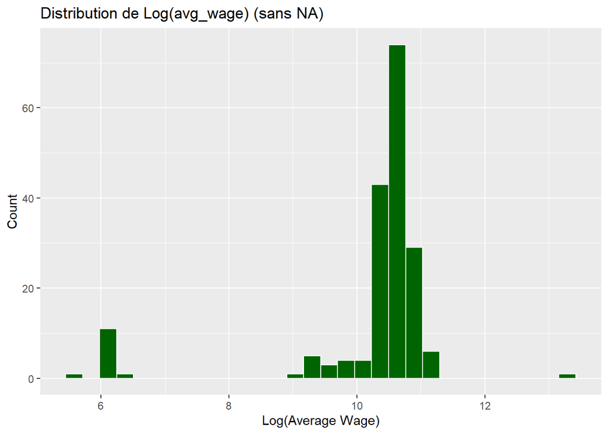

**Commentaire**: Cet histogramme montre la distribution des salaires moyens (`avg_wage`) en utilisant une transformation logarithmique pour réduire l’impact des valeurs extrêmes. Cela permet une meilleure visualisation de la répartition des salaires. On note que la distribution des salaires est relativement homogène, sauf pour des exceptions aux extrémités. Cela peut s'expliquer par le fait que la base de données englobe tout type d'emplois, comme les stages et les projets.

## 3. Boxplot de `avg_wage` par `sector_main`

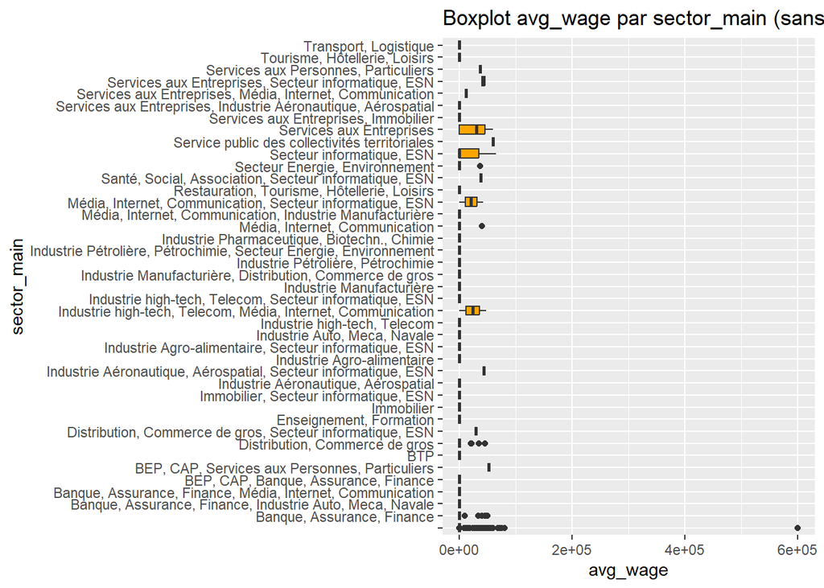

**Commentaire**: Ce boxplot compare les salaires moyens (`avg_wage`) entre différents secteurs (`sector_main`). Il met en évidence les médianes, la dispersion, ainsi que les outliers pour chaque secteur. La catégorie "Autre" affiche une importante disparité de salaires ,rendant la lecture des autres secteurs un peu plus complexe. Malgré cela, une vue d'ensemble des salaires analysés reste possible, notamment en notant l'absence de données sur certains secteurs, les variances, les salaires moyens et les quartiles.